# HW6 Po-Chun Chen N11957611

# Q1

Based on Aho textbook exercise 10.5. Answer parts (a) through (f), with the following instructions, hints, and modifications. In part(b) use R’s model.matrix() function. The syntax is a bit tricky. The default contrasts are the ones to be used, so there is no need to enter them. The syntax is  
X<-model.matrix(lifespan~treatment,data=life.exp)  
To compute the $\hat\beta$ (or $b$) vector, use Equataion (10.23), and use Equation (10.24) to compute $\hat Y$. In part (d), Ahoe means for you to rune the lm() function on hte data first, save the output, and then run the anova() function on this output. In part (e) conduct and summarize the first 2 diagnostic procedures, and comment on the outcome. If the output of your call to the lm() function is lm.out, then the first 2 diagnost plots would be created with R command plot(lmout,which=1:2). In part (f), run all possible pairwise tests using Tukey’s Honestly Significan Difference procedure with the function TukeyHSD(). Apply TukeyHSD to the output you obtain by doing an analysis of variance with the aov() function (applied in the same manner as the lm() function). Use the defualt 95% (family-wise) confidence intervals. Summarize the conclusions of this procedure.

### a. What are the correct hypotheses?

Null hypothesis(H0): $\mu1$ = $\mu2$ =$\mu3$ = $\mu4$, means are all the same  
Alternative hypothesis(HA): At least one $\mu i$ not equal to the others

### b. Calculate the SSE and SSA by hand (without using lm, anova, or aov).

First way:

```r
library(asbio)
data(life.exp)
X<-model.matrix(lifespan~treatment,data=life.exp)
Y<-life.exp$lifespan
beta.hat <- solve(t(X)%*% X)%*% t(X)%*% Y
I<-matrix(1,length(life.exp$lifespan),length(life.exp$lifespan))
SSA<-t(beta.hat)%*% t(X)%*% Y-(1/length(life.exp$lifespan))%*%t(Y)%*%I%*%Y
print(SSA)
```

```
##         [,1]
## [1,] 5267.03
```

```r
SSE<-(t(Y)%*% Y - t(beta.hat)%*% t(X)%*% Y)
print(SSE)
```

```
##          [,1]
## [1,] 10802.94
```

Second way:

```r
str(life.exp)
```

```
## 'data.frame':    244 obs. of  2 variables:
##  $ lifespan : num  42.3 40.1 39.5 38.6 38.4 ...
##  $ treatment: Factor w/ 4 levels "N/N85","N/R40",..: 1 1 1 1 1 1 1 1 1 1 ...
```

```r
n.i_life <-print(with(life.exp,tapply(lifespan, treatment, length)))
```

```
## N/N85 N/R40 N/R50 R/R50
##    57    60    71    56
```

```r
Ybar.i_life <- print(with(life.exp, tapply(lifespan, treatment, mean)))
```

```
##    N/N85    N/R40    N/R50    R/R50
## 32.69123 45.11667 42.29718 42.88571
```

```r
Ybar_life <- print(with(life.exp, mean(lifespan)))
```

```
## [1] 40.88156
```

```r
SSA_life <- print(sum(n.i_life * (Ybar.i_life - Ybar_life)^2))
```

```
## [1] 5267.03
```

```r
SSE_life <- print(with(life.exp, sum((lifespan - rep(Ybar.i_life[c(1, 3, 4, 2)],n.i_life[c(1, 3, 4, 2)]))^2)))
```

```
## [1] 10802.94
```

### c. Create the ANOVA table by hand, calculate $F^*$ and calculate the P -value. What do you conclude?

```r
MMA_life <- print(SSA_life/3)
```

```
## [1] 1755.677
```

```r
MME_life <- print(SSE_life/240)
```

```
## [1] 45.01224
```

```r
F_life<-print(MMA_life/MME_life)
```

```
## [1] 39.00443
```

```r
pf(F_life, 3, 240, lower.tail = F)
```

```
## [1] 1.438905e-20
```

| Source of Variation | df | SS | MS | F* |
| --- | --- | --- | --- | --- |
| Among groups | a-1=3 | 5267.03 | 1755.677 | 39.00443 |
| Within groups | n-a=240 | 10802.94 | 45.01224 |  |
| Total | n-1=243 |  |  |  |

The p-value is very small. Therefore, we can reject the null hypothesis

### d. Verify your results by running the ANOVA using lm and anova. Attach the results. Attach the results.

```r
lm_life<-lm(lifespan~treatment,data=life.exp)
anova(lm_life)
```

```
## Analysis of Variance Table
##
## Response: lifespan
##            Df Sum Sq Mean Sq F value    Pr(>F)
## treatment   3   5267 1755.68  39.004 < 2.2e-16 ***
## Residuals 240  10803   45.01
## ---
## Signif. codes:  0 '***' 0.001 '**' 0.01 '*' 0.05 '.' 0.1 ' ' 1
```

### e. Conduct and summarize the first 2 diagnostic procedures,and comment on the outcome.

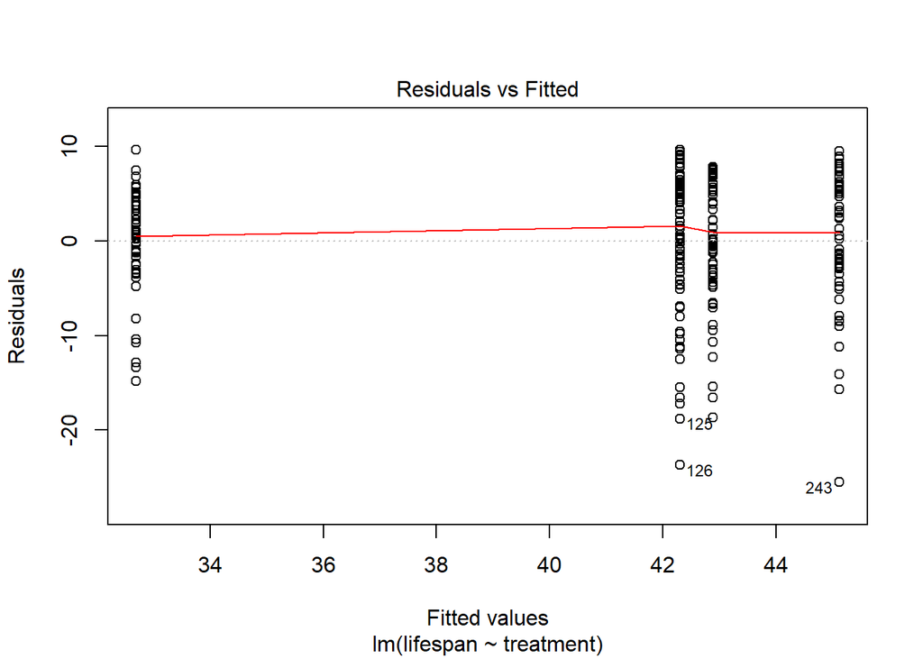

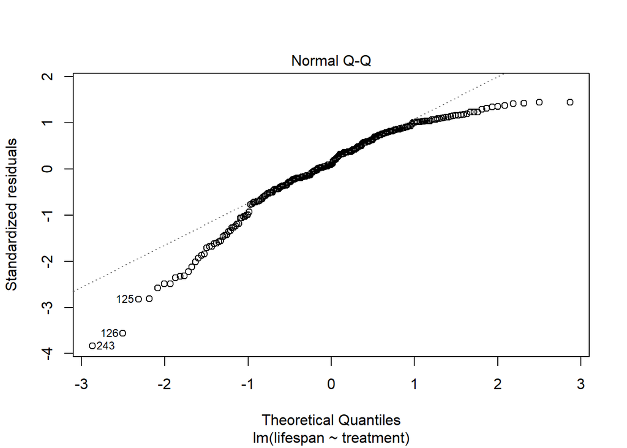

```r
plot(lm_life,which=1:2)
```

In residual vs Fitted plot, the plot allows you to see if the variability of the observations differs across the groups because all observations in the same group get the same fitted value

As the name suggests, this plot is used to determine the normal distribution of errors. It uses standardized values of residuals. Ideally, this plot should show a straight line. If you find a curved, distorted line, then your residuals have a non-normal distribution (problematic situation).

### f. Run all possible pairwise tests using Tukey’s Honestly Significan Difference procedure with the function TukeyHSD()

on the output you obtain by doing an analysis of variance with the aov() function applied in the same manner as the lm() functions. Use the defualt 95% (family.wise) confidence intervals. Summarize the conclusions of this procedure.

```r
# methods specific to ANOVA
par(mfrow=c(1,1))
TukeyHSD(aov(lm_life)) # (note: we need to convert lm to aov here as TukeyHSD is specific to ANOVA)
```

```
##   Tukey multiple comparisons of means
##     95% family-wise confidence level
##
## Fit: aov(formula = lm_life)
##
## $treatment
##                   diff       lwr        upr     p adj
## N/R40-N/N85 12.4254385  9.215018 15.6358589 0.0000000
## N/R50-N/N85  9.6059554  6.519071 12.6928401 0.0000000
## R/R50-N/N85 10.1944862  6.928685 13.4602879 0.0000000
## N/R50-N/R40 -2.8194831 -5.863260  0.2242942 0.0804712
## R/R50-N/R40 -2.2309523 -5.456039  0.9941344 0.2808243
## R/R50-N/R50  0.5885309 -2.513604  3.6906659 0.9610849
```

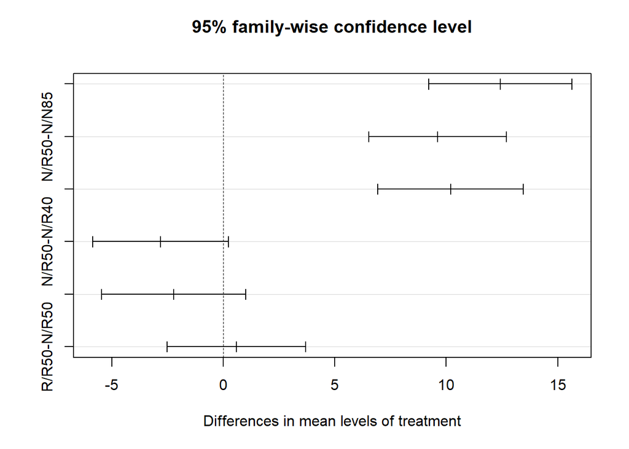

```r
plot(TukeyHSD(aov(lm_life), "treatment"))
```

The TukeyHSD compare the difference of mean for each group. In this case, we have four kinds of treatment. Therefore, it will generate 6 combinations for multiple testing. The p-value tells you if you can reject the null hypothesis. In other words, if the p-value is small enough, the means between groups are not equal. The plot clearly shows that comparison between groups with high p-value tend to have the 95% confidence interval around 0 (which is no difference).

# Q2

The juul data frame in the “ISwR” library has 1339 rows and 6 columns. It contains a reference sample of the distribution of insulin-like growth factor (IGF-I), one observation per subject in various ages, with the bulk of the data collected in connection with school physical examinations.

### a. Perform a one-way anova

Perform a one-way anova with the explanatory variable being the tanner variable, which is a 5-level factor giving an estimation of the stage of puberty based on the Tanner scale, and with a response variable of igf1 which is numeric and which measures insulin-like growth factor (micrograms/l). You may use the lm() and anova() functions.

```r
library(ISwR)
data(juul)
juul$tanner <- factor(juul$tanner, labels=c("I","II","III","IV","V"))
summary(juul$tanner)
```

```
##    I   II  III   IV    V NA's
##  515  103   72   81  328  240
```

```r
anova(lm(igf1~tanner,data=juul)) # degree of freedoms are actually 4
```

```
## Analysis of Variance Table
##
## Response: igf1
##            Df   Sum Sq Mean Sq F value    Pr(>F)
## tanner      4 12696217 3174054  228.35 < 2.2e-16 ***
## Residuals 787 10939116   13900
## ---
## Signif. codes:  0 '***' 0.001 '**' 0.01 '*' 0.05 '.' 0.1 ' ' 1
```

### b. Interpret the overall (omnibus) p-value.

The p-value is extremely small that we can reject the null hypothesis. In other words, at least one group of the mean difference of igf1 value for each group is not the same(not 0).

```r
anova_juul<- anova(lm(igf1~tanner,data=juul))
print(anova_juul$'Pr(>F)')
```

```
## [1] 4.678213e-130            NA
```

### c. Compute the F-statistic and (omnibus) p-value

Compute the F-statistic and (omnibus) p-value directly from the definition of the F-statistic, without using the anova() function. Show your working.

```r
library(ISwR)
data(juul)
juul2<- juul[!with(juul,is.na(igf1)| is.na(tanner)),]
# Compute the F-statistic and (omnibus) p-value
juul2<- juul2[order(juul2$tanner),]
str(juul2)
```

```
## 'data.frame':    792 obs. of  6 variables:
##  $ age     : num  0.17 0.17 0.17 0.17 0.17 0.17 0.17 0.25 0.25 0.42 ...
##  $ menarche: int  NA NA NA NA NA NA NA NA NA NA ...
##  $ sex     : num  1 1 1 1 1 1 1 1 1 1 ...
##  $ igf1    : num  101 97 106 111 79 43 64 90 141 42 ...
##  $ tanner  : int  1 1 1 1 1 1 1 1 1 1 ...
##  $ testvol : int  NA NA NA NA NA NA NA NA NA NA ...
```

```r
juul_puberty <-print(with(juul2,tapply(igf1, tanner, length)))
```

```
##   1   2   3   4   5
## 311  70  45  58 308
```

```r
Ybar.i_puberty <- print(with(juul2, tapply(igf1, tanner, mean)))
```

```
##        1        2        3        4        5
## 207.4727 352.6714 483.2222 513.0172 465.3344
```

```r
Ybar_puberty <- print(with(juul2, mean(igf1)))
```

```
## [1] 358.6288
```

```r
SSA_puberty <- print(sum(juul_puberty * (Ybar.i_puberty - Ybar_puberty)^2))
```

```
## [1] 12696217
```

```r
SSE_puberty <- print(with(juul2, sum((igf1 - rep(Ybar.i_puberty[c(1, 2, 3, 4, 5)],juul_puberty[c(1, 2, 3, 4, 5)]))^2)))
```

```
## [1] 10939116
```

```r
MMA_puberty <- print(SSA_puberty/4)
```

```
## [1] 3174054
```

```r
MME_puberty <- print(SSE_puberty/787)
```

```
## [1] 13899.77
```

```r
F_puberty<-print(MMA_puberty/MME_puberty)
```

```
## [1] 228.3531
```

```r
pf(F_puberty, 4, 787, lower.tail = F)
```

```
## [1] 4.678213e-130
```

### d. If suitable, also analyse pairwise comparisons between levels of the Tanner factor, and plot corresponding 95% confidence intervals.

```r
library(ISwR)
data(juul)
par(mfrow=c(1,1))
juul$tanner <- factor(juul$tanner, labels=c("I","II","III","IV","V"))
puberty_lm<-lm(igf1~tanner,data=juul)
TukeyHSD(aov(puberty_lm)) # (note: we need to convert lm to aov here as TukeyHSD is specific to ANOVA)
```

```
##   Tukey multiple comparisons of means
##     95% family-wise confidence level
##
## Fit: aov(formula = puberty_lm)
##
## $tanner
##             diff       lwr        upr     p adj
## II-I   145.19876 102.55521 187.842307 0.0000000
## III-I  275.74955 224.33825 327.160855 0.0000000
## IV-I   305.54457 259.44053 351.648619 0.0000000
## V-I    257.86175 231.94922 283.774277 0.0000000
## III-II 130.55079  68.96030 192.141289 0.0000001
## IV-II  160.34581 103.11077 217.580857 0.0000000
## V-II   112.66299  69.98130 155.344674 0.0000000
## IV-III  29.79502 -34.24013  93.830166 0.7084487
## V-III  -17.88781 -69.33075  33.555134 0.8768039
## V-IV   -47.68283 -93.82215  -1.543501 0.0387805
```

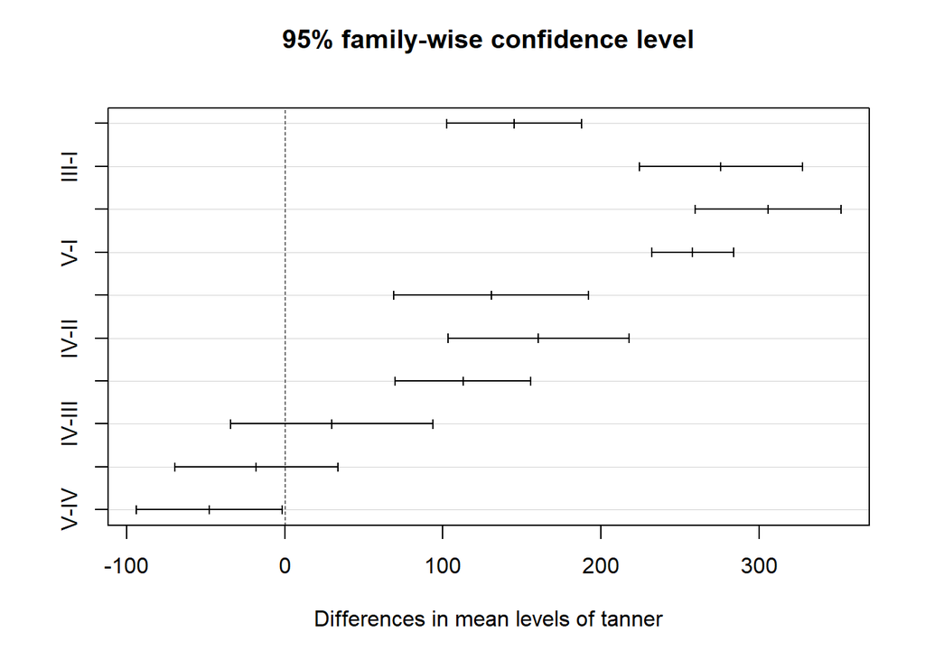

```r
plot(TukeyHSD(aov(puberty_lm), "tanner"))
```

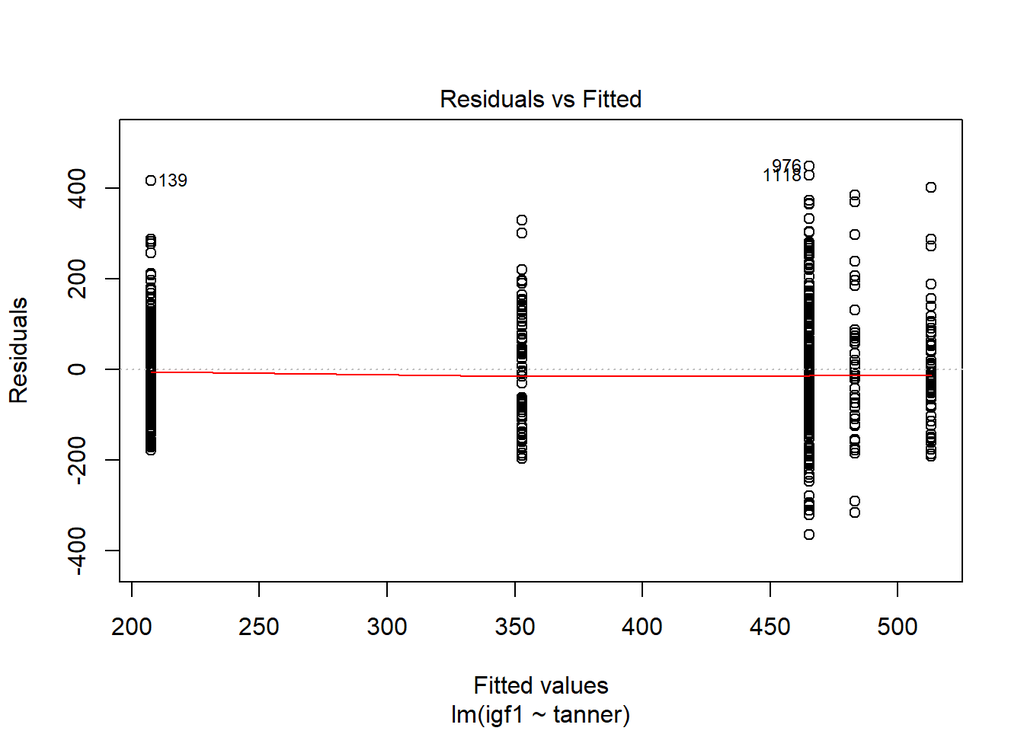

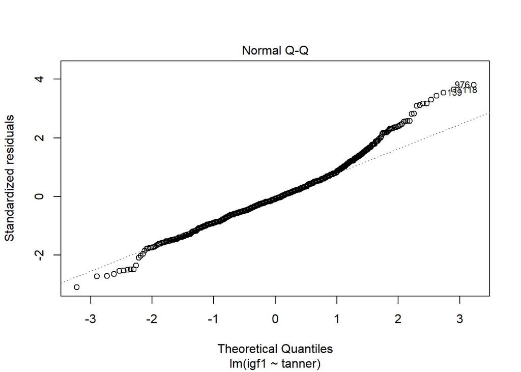

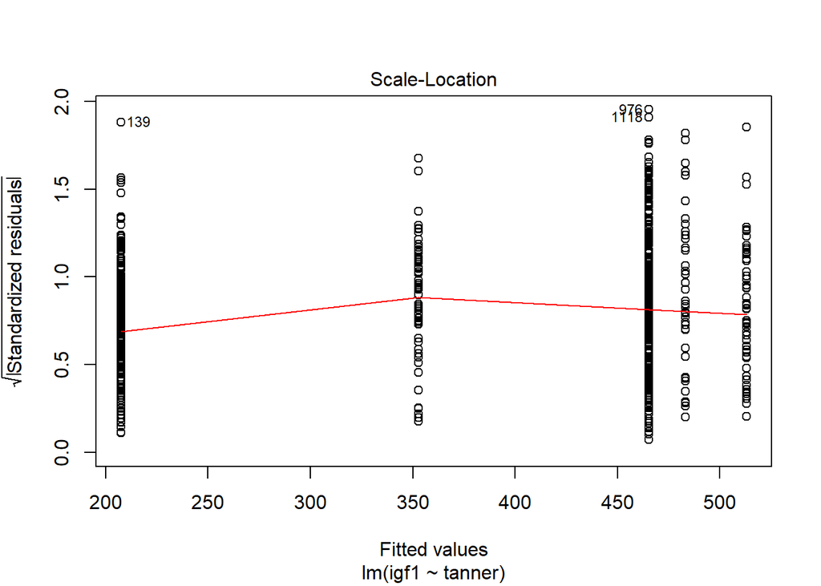

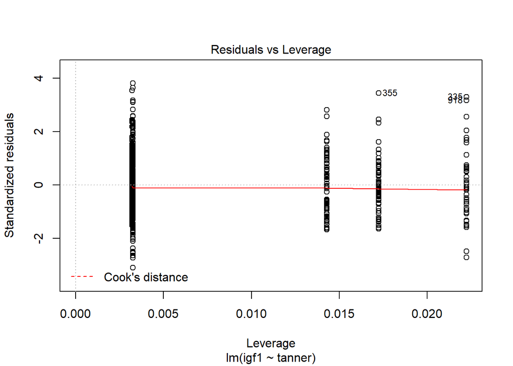

```r
plot(puberty_lm)
```

Note: consider multiple testing correction.

```r
library(ISwR)
data(juul)
juul2<- juul[!with(juul,is.na(igf1)| is.na(tanner)),]
# Compute the F-statistic and (omnibus) p-value
juul2<- juul2[order(juul2$tanner),]
pairwise.t.test(juul2$igf1, juul2$tanner, p.adj="bonferroni")
```

```
##
##  Pairwise comparisons using t tests with pooled SD
##
## data:  juul2$igf1 and juul2$tanner
##
##   1       2       3     4
## 2 < 2e-16 -       -     -
## 3 < 2e-16 9.9e-08 -     -
## 4 < 2e-16 5.5e-13 1.000 -
## 5 < 2e-16 1.3e-11 1.000 0.048
##
## P value adjustment method: bonferroni
```

```r
pairwise.t.test(juul2$igf1, juul2$tanner, p.adj="holm")
```

```
##
##  Pairwise comparisons using t tests with pooled SD
##
## data:  juul2$igf1 and juul2$tanner
##
##   1       2       3     4
## 2 < 2e-16 -       -     -
## 3 < 2e-16 3.9e-08 -     -
## 4 < 2e-16 3.3e-13 0.407 -
## 5 < 2e-16 6.3e-12 0.407 0.015
##
## P value adjustment method: holm
```

```r
pairwise.t.test(juul2$igf1, juul2$tanner, p.adj="none")
```

```
##
##  Pairwise comparisons using t tests with pooled SD
##
## data:  juul2$igf1 and juul2$tanner
##
##   1       2       3      4
## 2 < 2e-16 -       -      -
## 3 < 2e-16 9.9e-09 -      -
## 4 < 2e-16 5.5e-14 0.2037 -
## 5 < 2e-16 1.3e-12 0.3420 0.0048
##
## P value adjustment method: none
```

Multiple testing correction refers to re-calculating probabilities obtained from a statistical test which was repeated multiple times. In order to retain a prescribed family-wise error rate α in an analysis involving more than one comparison, the error rate for each comparison must be more stringent than α. Boole’s inequality implies that if each of m tests is performed to have type I error rate α/m, the total error rate will not exceed α. This is called the Bonferroni correction, and is one of the most commonly used approaches for multiple comparisons.

Note: use str() on the dataset first to check variable types are correct. Note: make sure you perform diagnostic plots. Note: consider multiple testing correction.